UFSM: 2018/1; Notas de aula: Mecânica Quântica; Autor: Jonas Maziero

```python
import numpy as np
from matplotlib import pyplot as plt
from sympy import *
init_printing(use_unicode=True)
```

# Partícula de spin 1/2 em um campo magnético

Considerando o protótipo clássico de dipolo magnético, a espira de corrente, obtemos a seguinte relação entre momento de dipolo magnético e momento angular (**exercício**) \begin{equation} \vec{\mu} = \frac{q}{2m}\vec{L}. \end{equation} Para descrever "distribuições mais complicadas de corrente", corrigimos esta expressão usando o fator giromagnético $g$, que deve ser determinado experimentalmente para cada sistema físico (e.g. $g \approx −2.0023$ para o elétron, $g \approx 5.586$ para o próton e $g \approx −3.826$ para o nêutron). Assim, \begin{equation} \vec{\mu} = \frac{gq}{2m}\vec{L}. \end{equation} Quando nos referimos ao momento angular intrínseco, o spin, usamos em geral $\vec{S}$, que por sua vez é escrito em termos de um outro operador como $\vec{S}=(\hbar/2)\vec{\Gamma}$. Juntando tudo segue \begin{equation} \vec{\mu} = \frac{\hbar gq}{4m}\vec{\Gamma}. \end{equation}

A energia potencial de interação entre um momento e um campo magnético é dada por: \begin{equation} U = -\vec{\mu}\cdot\vec{B} = -\frac{\hbar gqB}{4m}\vec{\Gamma}.\hat{n}_{B} = -\frac{\hbar\omega}{2}\vec{\Gamma}.\hat{n}_{B} = H, \end{equation} onde definimos a *frequência de Larmor* \begin{equation} \omega = \frac{g q B}{2m}, \end{equation} que nos fornece a intensidade da interação entre $\vec{\mu}$ e $\vec{B}$. Por sua vez, a força sobre uma partícula interagindo dessa forma será \begin{equation} \vec{F} = -\vec{\nabla}U = \sum_{j=x,y,z}\mu_{j}\vec{\nabla}B_{j}. \end{equation}

## Estados e observáveis de um spin 1/2

Em experimentos de Stern e Gerlach, observa-se a quantização do spin fazendo-se partículas de spin 1/2 atravessar uma região com um gradiente de campo magnético, e observando que somente dois feixes de partículas bem separados resultavam dessa interação.

Consideremos primeiro que o gradiente de campo é "aplicado" na direção $z$ (e $B_{x}=B_{y}=0$), i.e., \begin{equation} \vec{B}= B_{z}\hat{k}= Bz\hat{k}. \end{equation} Então $F_{x}=F_{y}=0$ e \begin{equation} F_{z}=\mu_{z}\partial_{z}B_{z}=\mu_{z}B. \end{equation} Como as partículas são desviadas pra cima ou pra baixo, temos duas possibilidades para os estados preparados medindo o observável "componente de spin na direção $z$", que denotaremos por $\sigma_{z}$. Isso nos indica que \begin{equation} \text{Espaço de estados } = \mathbb{C}^{2}. \end{equation} Vamos denotar os estados preparados pela medida de $\sigma_{z}$ (que deve ser representado por um operador Hermitiano) por \begin{equation} \begin{cases} \text{ partícula desviada pra cima em z} \Rightarrow |z_{+}\rangle \text{ foi preparado}, \\ \text{ partícula desviada pra baixo em z} \Rightarrow |z_{-}\rangle \text{ foi preparado}. \end{cases} \end{equation} Normalizaremos os autovalores para obter \begin{equation} \begin{cases} \text{ partícula desviada pra cima em z} \Rightarrow z_{+} = +1, \\ \text{ partícula desviada pra baixo em z} \Rightarrow z_{-} = -1. \end{cases} \end{equation} Por conseguinte, o operador $\sigma_{z}$ e sua representação matricial (**exercício**) ficam: \begin{equation} \sigma_{z} = z_{+}|z_{+}\rangle\langle z_{+}| + z_{-}|z_{-}\rangle\langle z_{-}| = \begin{bmatrix} 1 & 0 \\ 0 & -1 \end{bmatrix}, \end{equation} na base ortonormal $\{|z_{+}\rangle,|z_{-}\rangle\}$.

*OBS:* Em qualquer direção que se coloque o gradiente de campo magnético, teremos dois feixes desviados com proporções iguais. Por conseguinte, os autovalores terão a mesma magnitude para medida da camponente do spin em qualquer direção.

Determina-se experimentalmente que se prepararmos as partículas no estado $|z_{+}\rangle$ ou $|z_{-}\rangle$ através da medida de $\sigma_{z}$ e depois as fizermos passar por um gradiente de $\vec{B}$ na direção $x$, metade destas serão desviadas pra cima e metade pra baixo. Seremos consistentes com a regra de Born se usarmos \begin{equation} |z_{\pm}\rangle = \sqrt{1/2}|x_{+}\rangle \pm \sqrt{1/2}|x_{-}\rangle. \\ \end{equation}

**Exercício:** Verifique que $|x_{\pm}\rangle = \sqrt{1/2}|z_{+}\rangle \pm \sqrt{1/2}|z_{-}\rangle$ e que eles formam uma base ortonormal.

Nesse caso o observável fica escrito como (**exercício**) \begin{equation} \sigma_{x} = x_{+}|x_{+}\rangle\langle x_{+}| + x_{-}|x_{-}\rangle\langle x_{-}| = |z_{+}\rangle\langle z_{-}| + |z_{-}\rangle\langle z_{+}| = \begin{bmatrix} 0 & 1 \\ 1 & 0 \end{bmatrix}, \end{equation} na base $\{|z_{+}\rangle,|z_{-}\rangle\}$.

Também é um fato empírico que se preparamos as partículas em qualquer um dos estados $|z_{\pm}\rangle,|x_{\pm}\rangle$ e as fizermos passar por um gradiente de $\vec{B}$ na direção $y$, a probabilidade de desvio pra cima ou pra baixo é $1/2$. A única opção que temos agora é usar coeficientes complexos para manter consistência com a regra de Born: \begin{equation} |y_{\pm}\rangle = \sqrt{1/2}|z_{+}\rangle \pm i\sqrt{1/2}|z_{-}\rangle, \end{equation} com $i=\sqrt{-1}$. Isso nos retorna (**exercício**) \begin{equation} \sigma_{y} = y_{+}|y_{+}\rangle\langle y_{+}| + y_{-}|y_{-}\rangle\langle y_{-}| = -i|z_{+}\rangle\langle z_{-}| + i|z_{-}\rangle\langle z_{+}| = \begin{bmatrix} 0 & -i \\ i & 0 \end{bmatrix}, \end{equation} na base $\{|z_{+}\rangle,|z_{-}\rangle\}$.

**Exercício:** Verifique que $|z_{+}\rangle = (1/\sqrt{2})(|y_{+}\rangle+|y_{-}\rangle)$, $|z_{-}\rangle = (-i/\sqrt{2})(|y_{+}\rangle-|y_{-}\rangle)$, $|y_{\pm}\rangle = ((1\pm i)/2)|x_{+}\rangle + ((1\mp i)/2)|x_{-}\rangle$, $|x_{\pm}\rangle = ((1\mp i)/2)|y_{+}\rangle + ((1\pm i)/2)|y_{-}\rangle$.

Agora, para descrever a componente do spin 1/2 em uma *direção qualquer* consideramos o vetor de Pauli \begin{equation} \vec{\sigma}=\hat{i}\sigma_{x}+\hat{j}\sigma_{y}+\hat{k}\sigma_{z} \end{equation} e o vetor unitário naquela direção ($\theta\in[0,\pi/2]$, $\phi\in[0,2\pi]$), \begin{equation} \hat{n}=\hat{i}n_{x}+\hat{j}n_{y}+\hat{k}n_{z} = \hat{i}\sin\theta\cos\phi+\hat{j}\sin\theta\sin\phi+\hat{k}\cos\theta, \end{equation} para escrever (**exercício**) \begin{equation} \hat{n}\cdot\vec{\sigma} = \sigma_{x}\sin\theta\cos\phi + \sigma_{y}\sin\theta\sin\phi + \sigma_{z}\cos\theta = \begin{bmatrix} \cos\theta & e^{-i\phi}\sin\theta \\ e^{i\phi}\sin\theta & -\cos\theta \end{bmatrix}, \end{equation} cujos autovalores são $n_{\pm}=\pm 1$ e autovetores podem ser expressos como (**exercício**): \begin{align} |n_{+}\rangle & = \cos(\theta/2)|z_{+}\rangle + e^{i\phi}\sin(\theta/2)|z_{-}\rangle, \\ |n_{-}\rangle & = \sin(\theta/2)|z_{+}\rangle - e^{i\phi}\cos(\theta/2)|z_{-}\rangle. \end{align}

```python
def Pauli(j):
    if j == 0:
        return Matrix([[1,0],[0,1]])
    elif j == 1:
        return Matrix([[0,1],[1,0]])
    elif j == 2:
        return Matrix([[0,-1j],[1j,0]])
    elif j == 3:
        return Matrix([[1,0],[0,-1]])
th, ph = symbols('theta phi')
NS = sin(th)*cos(ph)*Pauli(1) + sin(th)*sin(ph)*Pauli(2) + cos(th)*Pauli(3)
simplify(NS)
```

$$\left[\begin{matrix}\cos{\left (\theta \right )} & 1.0 e^{- i \phi} \sin{\left (\theta \right )}\\1.0 e^{i \phi} \sin{\left (\theta \right )} & - \cos{\left (\theta \right )}\end{matrix}\right]$$

```python
NS.eigenvects()
```

$$\left [ \left ( -1.0, \quad 1, \quad \left [ \left[\begin{matrix}- \frac{1}{\cos{\left (\theta \right )} + 1.0} \left(- i \sin{\left (\phi \right )} \sin{\left (\theta \right )} + \sin{\left (\theta \right )} \cos{\left (\phi \right )}\right)\\1.0\end{matrix}\right]\right ]\right ), \quad \left ( 1.0, \quad 1, \quad \left [ \left[\begin{matrix}- \frac{1}{\cos{\left (\theta \right )} - 1.0} \left(- i \sin{\left (\phi \right )} \sin{\left (\theta \right )} + \sin{\left (\theta \right )} \cos{\left (\phi \right )}\right)\\1.0\end{matrix}\right]\right ]\right )\right ]$$

### Probabilidades e valores médios para o estado geral $|n_{+}\rangle$

Vamos considerar então que o sistema está preparado no estado $|n_{+}\rangle$. Pela regra de Born, teremos então que para medidas de $\sigma_{z}$, \begin{align} Pr(z_{+}|n_{+}) & = |\langle z_{+}|n_{+}\rangle|^{2} \\ & = |\langle z_{+}|(\cos(\theta/2)|z_{+}\rangle + e^{i\phi}\sin(\theta/2)|z_{-}\rangle)|^{2} \\ & = |\cos(\theta/2)\langle z_{+}|z_{+}\rangle + e^{i\phi}\sin(\theta/2)\langle z_{+}|z_{-}\rangle|^{2} \\ & = |\cos(\theta/2)(1) + e^{i\phi}\sin(\theta/2)(0)|^{2} \\ & = \cos^{2}(\theta/2) = (1 +\cos\theta)/2 = (1 + n_{z})/2.\\ Pr(z_{-}|n_{+}) & = |\langle z_{-}|n_{+}\rangle|^{2} = |e^{i\phi}\sin(\theta/2)|^{2} = \sin^{2}(\theta/2) = (1 -\cos\theta)/2 = (1 - n_{z})/2. \end{align} Note que poderíamos ter obtido o último resultado usando $Pr(z_{+}|n_{+})+Pr(z_{-}|n_{+})=1$.

Para medidas de $\sigma_{x}$, \begin{align} Pr(x_{+}|n_{+}) & = |\langle x_{+}|(\cos(\theta/2)|z_{+}\rangle + e^{i\phi}\sin(\theta/2)|z_{-}\rangle)|^{2} \\ & = |\cos(\theta/2)\langle x_{+}|z_{+}\rangle + e^{i\phi}\sin(\theta/2)\langle x_{+}|z_{-}\rangle|^{2} \\ & = |\cos(\theta/2)(1/\sqrt{2}) + e^{i\phi}\sin(\theta/2)(1/\sqrt{2})|^{2} \\ & = (1/2)\left(\cos(\theta/2) + e^{i\phi}\sin(\theta/2)\right)\left(\cos(\theta/2) + e^{-i\phi}\sin(\theta/2)\right) \\ & = \left(\cos^{2}(\theta/2) + e^{-i\phi}\sin(\theta/2)cos(\theta/2) + e^{i\phi}\sin(\theta/2)cos(\theta/2) + \sin^{2}(\theta/2)\right)/2 \\ & = \left(1 + \sin(\theta/2)cos(\theta/2)(\cos\phi -i\sin\phi +\cos\phi + i\sin\phi)\right)/2 \\ & = \left(1 + 2sin(\theta/2)\cos(\theta/2)\cos\phi\right)/2 \\ & = \left(1 + sin\theta\cos\phi\right)/2 \\ & = (1+n_{x})/2. \\ Pr(x_{-}|n_{+}) & = 1-Pr(x_{+}|n_{+}) = (1-n_{x})/2. \end{align}

Para medidas de $\sigma_{y}$ (**exercício**), \begin{align} Pr(y_{+}|n_{+}) & = (1/2)(1 + sin\theta\sin\phi) = (1+n_{y})/2 \\ Pr(y_{-}|n_{+}) & = 1-Pr(y_{+}|n_{+}) = (1-n_{y})/2. \end{align}

Com isso podemos calcular os *valores médios:* \begin{align} \langle\sigma_{z}\rangle_{n_{+}} & = (+1)Pr(z_{+}|n_{+}) + (-1)Pr(z_{-}|n_{+}) \\ & = (1 + n_{z})/2 - (1 - n_{z})/2 \\ & = n_{z}. \\ \langle\sigma_{x}\rangle_{n_{+}} & = (+1)Pr(x_{+}|n_{+}) + (-1)Pr(x_{-}|n_{+}) \\ & = (1 + n_{x})/2 - (1 - n_{x})/2 \\ & = n_{x}. \\ \langle\sigma_{y}\rangle_{n_{+}} & = (+1)Pr(y_{+}|n_{+}) + (-1)Pr(y_{-}|n_{+}) \\ & = (1 + n_{y})/2 - (1 - n_{y})/2 \\ & = n_{y}. \end{align}

Já os *desvios padrões* associados a esses observáveis são obtidos como segue (lembrando $\sigma_{O}^{\psi} = \langle O^{2}\rangle_{\psi} - \langle O\rangle_{\psi}^{2}$): \begin{align} \langle\sigma_{z}^{2}\rangle_{n_{+}} & = (+1)^{2}Pr(z_{+}|n_{+}) + (-1)^{2}Pr(z_{-}|n_{+}) \\ & = Pr(z_{+}|n_{+}) + Pr(z_{-}|n_{+}) \\ & = 1 \\ & = \langle\sigma_{x}^{2}\rangle_{n_{+}} = \langle\sigma_{y}^{2}\rangle_{n_{+}}, \text{ (exercício)} \\ (\sigma_{\sigma_{z}}^{\psi})^{2} & = \langle \sigma_{z}^{2}\rangle_{\psi} - \langle \sigma_{z}\rangle_{\psi}^{2} \\ & = 1-n_{z}^{2} = 1 - \cos^{2}\theta \\ & = \sin^{2}\theta, \\ (\sigma_{\sigma_{x}}^{\psi})^{2} & = 1-n_{x}^{2} = 1 - \sin^{2}\theta\cos^{2}\phi, \\ (\sigma_{\sigma_{y}}^{\psi})^{2} & = 1-n_{y}^{2} = 1 - \sin^{2}\theta\cos^{2}\phi. \end{align}

## Precessão de spin na representação de Schrödinger (RS)

Vamos considerar a evolução temporal do spin 1/2 quando este está submetido a um campo magnético constante na direção $z$. Nesse caso o Hamiltoniano será \begin{equation} H = -\frac{\hbar\omega}{2}\vec{\sigma}\cdot\hat{k} = -\frac{\hbar\omega}{2}\sigma_{z} = \begin{bmatrix} -\frac{\hbar\omega}{2} & 0 \\ 0 & \frac{\hbar\omega}{2} \end{bmatrix} = -\frac{\hbar\omega}{2}|z_{+}\rangle\langle z_{+}| + \frac{\hbar\omega}{2}|z_{-}\rangle\langle z_{-}|. \end{equation}

Como o Hamiltoniano é independente do tempo, o operador de evolução temporal pode ser escrito como \begin{equation} U_{t} = e^{-iHt/\hbar} = e^{i\hbar\omega\sigma_{z}t/2\hbar} = e^{i\omega\sigma_{z}t/2}. \end{equation}

Vamos considerar que o sistema foi preparado no estado inicial $|n_{+}\rangle$. O estado evoluído do sistema será: \begin{align} |\psi_{t}\rangle & = U_{t}|\psi\rangle = U_{t}|n_{+}\rangle \\ & = U_{t}\left(\cos(\theta/2)|z_{+}\rangle + e^{i\phi}\sin(\theta/2)|z_{-}\rangle\right) \\ & = \cos(\theta/2)U_{t}|z_{+}\rangle + e^{i\phi}\sin(\theta/2)U_{t}|z_{-}\rangle \\ & = \cos(\theta/2)e^{i\omega\sigma_{z}t/2}|z_{+}\rangle + e^{i\phi}\sin(\theta/2)e^{i\omega\sigma_{z}t/2}|z_{-}\rangle \\ & = \cos(\theta/2)e^{i\omega t/2}|z_{+}\rangle + e^{i\phi}\sin(\theta/2)e^{-i\omega t/2}|z_{-}\rangle. \end{align}

**OBS:** Se multiplicamos o estado do sistema por uma *fase global*, *não modificamos as probabilidades* pois \begin{equation} Pr(o|e^{i\phi}\psi) = |\langle o|e^{i\phi}|\psi\rangle|^{2} = |e^{i\phi}|^{2}|\langle o|\psi\rangle|^{2} = |\langle o|\psi\rangle|^{2} = Pr(o|\psi). \end{equation}

Em vistas deste fato, vamos considerar \begin{align} |\psi_{t}\rangle & \equiv e^{-i\omega t/2}|\psi_{t}\rangle \\ & = \cos(\theta/2)|z_{+}\rangle + e^{i(\phi -\omega t)}\sin(\theta/2)|z_{-}\rangle \\ & = \cos(\theta_{t}/2)|z_{+}\rangle + e^{i\phi_{t}}\sin(\theta_{t}/2)|z_{-}\rangle. \end{align} Com isso podemos usar todos os resultados obtidos anteriormente, com as substituições \begin{align} & \theta\rightarrow\theta_{t}=\theta, \\ & \phi\rightarrow\phi_{t}=\phi-\omega t. \end{align} Vem então que (lembre que na RS os observáveis não mudam com $t$): \begin{align} Pr(z_{+}|\psi_{t}) & = (1+n_{z}(t))/2 = (1+\cos\theta_{t})/2 = (1+\cos\theta)/2 = Pr(z_{+}|\psi) = \text{ constante}, \\ \langle\sigma_{z}\rangle_{\psi_{t}} & = n_{z}(t) = \cos\theta_{t} = \cos\theta = \langle\sigma_{z}\rangle_{\psi} = \text{ constante}, \\ Pr(x_{+}|\psi_{t}) & = (1+n_{x}(t))/2 = (1+\sin\theta_{t}\cos\phi_{t})/2 = (1+\sin\theta\cos(\phi-\omega t))/2, \\ \langle\sigma_{x}\rangle_{\psi_{t}} & = n_{x}(t) = \sin\theta_{t}\cos\phi_{t} = \sin\theta\cos(\phi-\omega t), \\ Pr(y_{+}|\psi_{t}) & = (1+n_{y}(t))/2 = (1+\sin\theta_{t}\sin\phi_{t})/2 = (1+\sin\theta\sin(\phi-\omega t))/2, \\ \langle\sigma_{y}\rangle_{\psi_{t}} & = n_{y}(t) = \sin\theta_{t}\sin\phi_{t} = \sin\theta\sin(\phi-\omega t). \end{align}

**Exercício:** Faça esses mesmos cálculos (estado evoluído, probabilidades, valores médios, desvios padrões) considerando um campo magnético constante aplicado na direção $x$, e o spin 1/2 inicialmente em um estado genérico $|n_{+}\rangle$.

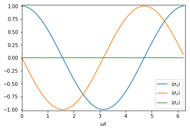

```python
theta, phi, wt, N = symbols('theta phi wt N')
theta = np.pi/2
phi = 0.0
N = 100
dwt = (2.*np.pi-0)/N
xavg = np.zeros(N)
yavg = np.zeros(N)
zavg = np.zeros(N)
wtv = np.zeros(N)
wt = -dwt
for j in range(0,N):
    wt += dwt
    wtv[j] = wt
    xavg[j] = sin(theta)*cos(phi-wtv[j])
    yavg[j] = sin(theta)*sin(phi-wtv[j])
    zavg[j] = cos(theta)
plt.plot(wtv, xavg, label=r'$\langle\sigma_{x}\rangle$')
plt.plot(wtv, yavg, label=r'$\langle\sigma_{y}\rangle$')
plt.plot(wtv, zavg, label=r'$\langle\sigma_{z}\rangle$')
plt.xlabel(r'$\omega t$')
axes = plt.gca()
axes.set_xlim([0,2*np.pi])
axes.set_ylim([-1.02,1.02])
plt.legend()
plt.show()
```

## Precessão de spin na representação de Heisenberg (RH)

Na RH, se o spin 1/2 foi preparado no estado $|n_{+}\rangle$, usaremos este mesmo vetor para calcular probabilidades em tempos posteriores. Por outro lado, evoluiremos os oberváveis. Para isso novamente usaremos \begin{equation} U_{t} = e^{i\omega\sigma_{z}t/2}= e^{i\omega t/2}|z_{+}\rangle\langle z_{+}| + e^{-i\omega t/2}|z_{-}\rangle\langle z_{-}|. \end{equation}

Para a **componente do spin na direção $z$**, \begin{align} |z_{+}(t)\rangle & = U_{t}^{\dagger}|z_{+}\rangle \\ & = (e^{-i\omega t/2}|z_{+}\rangle\langle z_{+}| + e^{i\omega t/2}|z_{-}\rangle\langle z_{-}|)|z_{+}\rangle \\ & = e^{-i\omega t/2}|z_{+}\rangle\langle z_{+}|z_{+}\rangle + e^{i\omega t/2}|z_{-}\rangle\langle z_{-}|z_{+}\rangle \\ & = e^{-i\omega t/2}|z_{+}\rangle, \\ |z_{-}(t)\rangle & = e^{i\omega t/2}|z_{-}\rangle. \end{align} Ou seja, este autovetores só ganham uma fase global. Teremos assim que as probabilidades são constantes para medidas de $\sigma_{z}$: \begin{align} Pr(z_{+}(t)|n_{+}) & = |\langle z_{+}(t)|n_{+}\rangle|^{2} \\ & = |e^{i\omega t/2}\langle z_{+}|n_{+}\rangle|^{2} \\ & = |\langle z_{+}|n_{+}\rangle|^{2} \\ & = Pr(z_{+}|n_{+}) \\ & = (1+n_{z})/2, \\ Pr(z_{-}(t)|n_{+}) & = (1-n_{z})/2. \end{align} O valor médio e desvio padrão são dados como na RS.

No caso da **componente do spin na direção $x$** vamos direto para o cálculo do valor médio \begin{equation} \langle\sigma_{x}(t)\rangle_{n_{+}} = \langle n_{+}| \sigma_{x}(t)|n_{+}\rangle, \end{equation} onde \begin{equation} \sigma_{x}(t) = U_{t}^{\dagger} \sigma_{x} U_{t} = e^{-i\omega\sigma_{z}t/2} \sigma_{x} e^{i\omega\sigma_{z}t/2}. \end{equation} Definindo $c=-i\omega t/2$ e usando a fórmula de Baker-Hausdroff, verificada abaixo, obtemos \begin{align} \sigma_{x}(t) & = e^{c\sigma_{z}}\sigma_{x}e^{-c\sigma_{z}} \\ & = \sigma_{x} + c[\sigma_{z},\sigma_{x}] + \frac{c^{2}}{2}[\sigma_{z},[\sigma_{z},\sigma_{x}]] + \frac{c^{3}}{3!}[\sigma_{z},[\sigma_{z},[\sigma_{z},\sigma_{x}]]] \\ & + \frac{c^{4}}{4!}[\sigma_{z},[\sigma_{z},[\sigma_{z},[\sigma_{z},\sigma_{x}]]]] + \frac{c^{5}}{5!}[\sigma_{z},[\sigma_{z},[\sigma_{z},[\sigma_{z},[\sigma_{z},\sigma_{x}]]]]] + \cdots. \end{align}

```python
def comm(x,y):
    return x*y - y*x
comm(Pauli(1),Pauli(2))
```

$$\left[\begin{matrix}2.0 i & 0\\0 & - 2.0 i\end{matrix}\right]$$

Como pode ser verificado usando o código acima, se usamos $\sigma_{1}=\sigma_{x},\sigma_{2}=\sigma_{y},\sigma_{3}=\sigma_{z}$, teremos a relação geral para comutadores envolvendo matrizes de Pauli \begin{equation} [\sigma_{j},\sigma_{k}] = 2i\epsilon_{jkl}\sigma_{l}, \end{equation} em que $\epsilon_{jkl}$ é o símbolo de Levi-Civita.

Com isso, $[\sigma_{z},\sigma_{x}]=[\sigma_{3},\sigma_{1}]=2i\epsilon_{312}\sigma_{2}=2i\sigma_{2}$ e $[\sigma_{z},\sigma_{y}]=[\sigma_{3},\sigma_{2}]=2i\epsilon_{321}\sigma_{1}=-2i\sigma_{1}$, e \begin{align} \sigma_{x}(t) & = \sigma_{x} + c2i\sigma_{y} + \frac{c^{2}}{2}2i[\sigma_{z},\sigma_{y}] + \frac{c^{3}}{3!}2i[\sigma_{z},[\sigma_{z},\sigma_{y}]] + \frac{c^{4}}{4!}2i[\sigma_{z},[\sigma_{z},[\sigma_{z},\sigma_{y}]]] + \frac{c^{5}}{5!}2i[\sigma_{z},[\sigma_{z},[\sigma_{z},[\sigma_{z},\sigma_{y}]]]] + \cdots \\ & = \sigma_{x} + c2i\sigma_{y} - \frac{c^{2}}{2}4i^{2}\sigma_{x} - \frac{c^{3}}{3!}4i^{2}[\sigma_{z},\sigma_{x}] - \frac{c^{4}}{4!}4i^{2}[\sigma_{z},[\sigma_{z},\sigma_{x}]] - \frac{c^{5}}{5!}4i^{2}[\sigma_{z},[\sigma_{z},[\sigma_{z},\sigma_{x}]]] + \cdots \\ & = \sigma_{x} + c2i\sigma_{y} - \frac{(2ic)^{2}}{2}\sigma_{x} - \frac{c^{3}}{3!}8i^{3}\sigma_{y} - \frac{c^{4}}{4!}8i^{3}[\sigma_{z},\sigma_{y}] - \frac{c^{5}}{5!}8i^{3}[\sigma_{z},[\sigma_{z},\sigma_{y}]] + \cdots \\ & = \sigma_{x} + c2i\sigma_{y} - \frac{(2ic)^{2}}{2}\sigma_{x} - \frac{c^{3}}{3!}8i^{3}\sigma_{y} + \frac{c^{4}}{4!}16i^{4}\sigma_{x} + \frac{c^{5}}{5!}16i^{4}[\sigma_{z},\sigma_{x}] + \cdots \\ & = \sigma_{x} + c2i\sigma_{y} - \frac{(2ic)^{2}}{2}\sigma_{x} - \frac{(2ic)^{3}}{3!}\sigma_{y} + \frac{(2ic)^{4}}{4!}\sigma_{x} + \frac{(2ic)^{5}}{5!}\sigma_{y} + \cdots \\ & = \sigma_{x}\left(1 - \frac{(2ic)^{2}}{2!} +\frac{(2ic)^{4}}{4!} + \cdots\right) + \sigma_{y}\left(2ci - \frac{(2ic)^{3}}{3!} + \frac{(2ic)^{5}}{5!} + \cdots\right) \\ & = \sigma_{x}\cos(2ci) + \sigma_{y}\sin(2ci) \\ & = \sigma_{x}\cos(2(-i\omega t/2)i) + \sigma_{y}\sin(2(-i\omega t/2)i) \\ & = \cos(\omega t)\sigma_{x} + \sin(\omega t)\sigma_{y}. \end{align} O valor médio é \begin{align} \langle\sigma_{x}(t)\rangle_{n_{+}} & = \cos(\omega t)\langle\sigma_{x}\rangle_{n_{+}} + \sin(\omega t)\langle\sigma_{y}\rangle_{n_{+}} \\ & = \cos(\omega t)n_{x} + \sin(\omega t)n_{y} \\ & = \cos(\omega t)\sin\theta\cos\phi + \sin(\omega t)\sin\theta\sin\phi \\ & = \sin\theta(\cos(\omega t)\cos\phi + \sin(\omega t)\sin\phi) \\ & = \sin\theta\cos(\phi-\omega t). \end{align}

**Exercício:** Obtenha $\langle\sigma_{y}(t)\rangle_{n_{+}}$ usando a fórmula de Baker-Hausdorff para calcular $\sigma_{y}(t)$.

### Fórmula de Baker-Hausdorff

Para $c\in\mathbb{C}$ e $A,B\in L(\mathcal{H})$ segue que \begin{equation} e^{cB}Ae^{-cB} = A + c[B,A] + \frac{c^{2}}{2!}[B,[B,A]] + \frac{c^{3}}{3!}[B,[B,[B,A]]] + \cdots. \end{equation} Vamos verificar essa igualdade expandindo a exponencial em série de Taylor: \begin{align} e^{cB}Ae^{-cB} & = \left(\sum_{j=0}^{\infty}\frac{(cB)^{j}}{j!}\right)A\left(\sum_{k=0}^{\infty}\frac{(-cB)^{k}}{k!}\right) \\ & = \left(\mathbb{I} + cB + \frac{c^{2}B^{2}}{2} + \frac{c^{3}B^{3}}{3!} + \cdots\right) A \left(\mathbb{I} - cB + \frac{c^{2}B^{2}}{2} - \frac{c^{3}B^{3}}{3!} + \cdots\right) \\ & = A + cBA - cAB + \frac{c^{2}B^{2}}{2}A + A\frac{c^{2}B^{2}}{2} - \frac{2}{2}cBAcB - \frac{c^{2}B^{2}}{2}AcB + cBA\frac{c^{2}B^{2}}{2} + \frac{c^{3}B^{3}}{3!}A - A\frac{c^{3}B^{3}}{3!} + \cdots \\ & = A + c[B,A] + \frac{c^{2}}{2}(BBA + ABB - 2BAB) + \frac{c^{3}}{3!}(BBBA - ABBB + 3BABB - 3BBAB) + \cdots \\ & = A + c[B,A] + \frac{c^{2}}{2}(B(BA-AB) + (AB-BA)B) + \frac{c^{3}}{3!}(BB(BA-AB) - (AB-BA)BB + 2B(ABB - BAB)) + \cdots \\ & = A + c[B,A] + \frac{c^{2}}{2}(B[B,A] - [B,A]B) + \frac{c^{3}}{3!}(BB[B,A] + [B,A]BB - 2B[B,A]B)) + \cdots \\ & = A + c[B,A] + \frac{c^{2}}{2}[B,[B,A]] + \frac{c^{3}}{3!}(B(B[B,A]-[B,A]B) + ([B,A]B-B[B,A])B) + \cdots \\ & = A + c[B,A] + \frac{c^{2}}{2}[B,[B,A]] + \frac{c^{3}}{3!}(B[B,[B,A]] - [B,[B,A]B) + \cdots \\ & = A + c[B,A] + \frac{c^{2}}{2!}[B,[B,A]] + \frac{c^{3}}{3!}[B,[B,[B,A]]] + \cdots. \end{align}